# Credit EDA Assignment Solution

## Business Understanding

The loan providing companies find it hard to give loans to the people due to their insufficient or non-existent credit history. Because of that, some consumers use it to their advantage by becoming a defaulter. Suppose you work for a consumer finance company which specialises in lending various types of loans to urban customers. You have to use EDA to analyse the patterns present in the data. This will ensure that the applicants capable of repaying the loan are not rejected.

When the company receives a loan application, the company has to decide for loan approval based on the applicant’s profile. Two types of risks are associated with the bank’s decision:

If the applicant is likely to repay the loan, then not approving the loan results in a loss of business to the company

If the applicant is not likely to repay the loan, i.e. he/she is likely to default, then approving the loan may lead to a financial loss for the company.

The data given below contains the information about the loan application at the time of applying for the loan. It contains two types of scenarios:

**The client with payment difficulties:** he/she had late payment more than X days on at least one of the first Y instalments of the loan in our sample,

**All other cases:** All other cases when the payment is paid on time.

When a client applies for a loan, there are four types of decisions that could be taken by the client/company):

**Approved:** The Company has approved loan Application

**Cancelled:** The client cancelled the application sometime during approval. Either the client changed her/his mind about the loan or in some cases due to a higher risk of the client, he received worse pricing which he did not want.

**Refused:** The company had rejected the loan (because the client does not meet their requirements etc.).

**Unused offer:** Loan has been cancelled by the client but at different stages of the process.

In this case study, you will use EDA to understand how consumer attributes and loan attributes influence the tendency to default.

## Business Objectives

This case study aims to identify patterns which indicate if a client has difficulty paying their instalments which may be used for taking actions such as denying the loan, reducing the amount of loan, lending (to risky applicants) at a higher interest rate, etc. This will ensure that the consumers capable of repaying the loan are not rejected. Identification of such applicants using EDA is the aim of this case study.

In other words, the company wants to understand the driving factors (or driver variables) behind loan default, i.e. the variables which are strong indicators of default. The company can utilise this knowledge for its portfolio and risk assessment.

To develop your understanding of the domain, you are advised to independently research a little about risk analytics - understanding the types of variables and their significance should be enough.

**This dataset has 3 files as explained below:**

1. 'application_data.csv' contains all the information of the client at the time of application. The data is about whether **a client has payment difficulties.**
2. 'previous_application.csv' contains information about the client’s previous loan data. It contains the data on whether the previous application had been **Approved, Cancelled, Refused or Unused offer.**
3. 'columns_description.csv' is data dictionary which describes the meaning of the variables.

## Table Of Content

1. Reading a Files
   - Application Data
   - Previous Application Data
2. Data Cleaning On Application Data
   - Checking Application Data Null Values
   - Handling Outlier For Application Data
3. Data Visualization
   - UNIVARIATE ANALYSIS
     - Plotting Categorical Columns
     - Insights From Categorical column
     - Plotting Numerical Columns
   - Bivariate & Multivariate Analysis
     - Insights From Analysis
4. Data Cleaning On Previous Application Data
5. Data Visualization on Previous Application Data
   - Insights On Previous Application
6. Merging the application Data and previous application data
7. Conclusion

```python
# Importing important libraries
import pandas as pd , numpy as np
import matplotlib.pyplot as plt
import seaborn as sns ; sns.set(color_codes = True)
import warnings
warnings.filterwarnings("ignore")
```

# Reading a Files

## Application Data

```python
# Reading Application Dataset
application_data = pd.read_csv("application_data.csv")
```

```python
# To Read All Rows And Columns
pd.set_option("display.max_columns",None)
#pd.set_option("display.max_rows",None)
```

```python
# Fetching Firat Five Columns
application_data.head()
```

|  | SK_ID_CURR | TARGET | NAME_CONTRACT_TYPE | CODE_GENDER | FLAG_OWN_CAR | FLAG_OWN_REALTY | CNT_CHILDREN | AMT_INCOME_TOTAL | AMT_CREDIT | AMT_ANNUITY | AMT_GOODS_PRICE | NAME_TYPE_SUITE | NAME_INCOME_TYPE | NAME_EDUCATION_TYPE | NAME_FAMILY_STATUS | NAME_HOUSING_TYPE | REGION_POPULATION_RELATIVE | DAYS_BIRTH | DAYS_EMPLOYED | DAYS_REGISTRATION | DAYS_ID_PUBLISH | OWN_CAR_AGE | FLAG_MOBIL | FLAG_EMP_PHONE | FLAG_WORK_PHONE | FLAG_CONT_MOBILE | FLAG_PHONE | FLAG_EMAIL | OCCUPATION_TYPE | … |
| --- | --- | --- | --- | --- | --- | --- | --- | --- | --- | --- | --- | --- | --- | --- | --- | --- | --- | --- | --- | --- | --- | --- | --- | --- | --- | --- | --- | --- | --- | --- |
| 0 | 100002 | 1 | Cash loans | M | N | Y | 0 | 202500.0 | 406597.5 | 24700.5 | 351000.0 | Unaccompanied | Working | Secondary / secondary special | Single / not married | House / apartment | 0.018801 | -9461 | -637 | -3648.0 | -2120 | NaN | 1 | 1 | 0 | 1 | 1 | 0 | Laborers | … |
| 1 | 100003 | 0 | Cash loans | F | N | N | 0 | 270000.0 | 1293502.5 | 35698.5 | 1129500.0 | Family | State servant | Higher education | Married | House / apartment | 0.003541 | -16765 | -1188 | -1186.0 | -291 | NaN | 1 | 1 | 0 | 1 | 1 | 0 | Core staff | … |
| 2 | 100004 | 0 | Revolving loans | M | Y | Y | 0 | 67500.0 | 135000.0 | 6750.0 | 135000.0 | Unaccompanied | Working | Secondary / secondary special | Single / not married | House / apartment | 0.010032 | -19046 | -225 | -4260.0 | -2531 | 26.0 | 1 | 1 | 1 | 1 | 1 | 0 | Laborers | … |
| 3 | 100006 | 0 | Cash loans | F | N | Y | 0 | 135000.0 | 312682.5 | 29686.5 | 297000.0 | Unaccompanied | Working | Secondary / secondary special | Civil marriage | House / apartment | 0.008019 | -19005 | -3039 | -9833.0 | -2437 | NaN | 1 | 1 | 0 | 1 | 0 | 0 | Laborers | … |
| 4 | 100007 | 0 | Cash loans | M | N | Y | 0 | 121500.0 | 513000.0 | 21865.5 | 513000.0 | Unaccompanied | Working | Secondary / secondary special | Single / not married | House / apartment | 0.028663 | -19932 | -3038 | -4311.0 | -3458 | NaN | 1 | 1 | 0 | 1 | 0 | 0 | Core staff | … |

```python
#shape of the data
application_data.shape
```

```
(307511, 122)
```

```python
# the info of all the columns
application_data.info()
```

```
<class 'pandas.core.frame.DataFrame'>
RangeIndex: 307511 entries, 0 to 307510
Columns: 122 entries, SK_ID_CURR to AMT_REQ_CREDIT_BUREAU_YEAR
dtypes: float64(65), int64(41), object(16)
memory usage: 286.2+ MB
```

## Data Cleaning On Application Data

## Checking Application Data Null Values

lets check the missing value one by one

```python
# shows how much percentage of data are null
(application_data.isnull().sum()/application_data.shape[0]*100).sort_values(ascending = False)
```

```
COMMONAREA_MEDI             69.872297
COMMONAREA_AVG              69.872297
COMMONAREA_MODE             69.872297
NONLIVINGAPARTMENTS_MODE    69.432963
NONLIVINGAPARTMENTS_AVG     69.432963
                              ...
NAME_HOUSING_TYPE            0.000000
NAME_FAMILY_STATUS           0.000000
NAME_EDUCATION_TYPE          0.000000
NAME_INCOME_TYPE             0.000000
SK_ID_CURR                   0.000000
Length: 122, dtype: float64
```

```python
# Lets See the columns who has more than 40 % of data with Null values
cut_off=40
cols_to_drop=list(application_data.columns[100*application_data.isnull().mean()>cut_off])
print(cols_to_drop)
```

```
['OWN_CAR_AGE', 'EXT_SOURCE_1', 'APARTMENTS_AVG', 'BASEMENTAREA_AVG', 'YEARS_BEGINEXPLUATATION_AVG', 'YEARS_BUILD_AVG', 'COMMONAREA_AVG', 'ELEVATORS_AVG', 'ENTRANCES_AVG', 'FLOORSMAX_AVG', 'FLOORSMIN_AVG', 'LANDAREA_AVG', 'LIVINGAPARTMENTS_AVG', 'LIVINGAREA_AVG', 'NONLIVINGAPARTMENTS_AVG', 'NONLIVIN…
```

```python
len(cols_to_drop)
```

```
49
```

##### As we can see there are 49 columns in application dataset which has more than 40% of data has NULL values, so we need to drop those columns are not required for analysis

```python
application_data.drop(columns =cols_to_drop, axis=1, inplace = True )
```

```python
application_data.shape
```

```
(307511, 73)
```

```python
application_data.info()
```

```
<class 'pandas.core.frame.DataFrame'>
RangeIndex: 307511 entries, 0 to 307510
Data columns (total 73 columns):
 #   Column                       Non-Null Count   Dtype
---  ------                       --------------   -----
 0   SK_ID_CURR                   307511 non-null  int64
 1   TARGET                       307511 non-null  int64
 2   NAME_CONTRACT_TYPE           307511 non-null  object
 3   CODE_GENDER                  307511 non-null  object
 4   FLAG_OWN_CAR                 307511 non-null  object
 5   FLAG_OWN_REALTY              307511 non-null  object
 6   CNT_CHILDREN                 307511 non-null  int64
 7   AMT_INCOME_TOTAL             307511 non-null  float64
 8   AMT_CREDIT                   307511 non-null  float64
 9   AMT_ANNUITY                  307499 non-null  float64
```

[output cut: 65 more lines]

```python
application_data.head()
```

|  | SK_ID_CURR | TARGET | NAME_CONTRACT_TYPE | CODE_GENDER | FLAG_OWN_CAR | FLAG_OWN_REALTY | CNT_CHILDREN | AMT_INCOME_TOTAL | AMT_CREDIT | AMT_ANNUITY | AMT_GOODS_PRICE | NAME_TYPE_SUITE | NAME_INCOME_TYPE | NAME_EDUCATION_TYPE | NAME_FAMILY_STATUS | NAME_HOUSING_TYPE | REGION_POPULATION_RELATIVE | DAYS_BIRTH | DAYS_EMPLOYED | DAYS_REGISTRATION | DAYS_ID_PUBLISH | FLAG_MOBIL | FLAG_EMP_PHONE | FLAG_WORK_PHONE | FLAG_CONT_MOBILE | FLAG_PHONE | FLAG_EMAIL | OCCUPATION_TYPE | CNT_FAM_MEMBERS | … |
| --- | --- | --- | --- | --- | --- | --- | --- | --- | --- | --- | --- | --- | --- | --- | --- | --- | --- | --- | --- | --- | --- | --- | --- | --- | --- | --- | --- | --- | --- | --- |
| 0 | 100002 | 1 | Cash loans | M | N | Y | 0 | 202500.0 | 406597.5 | 24700.5 | 351000.0 | Unaccompanied | Working | Secondary / secondary special | Single / not married | House / apartment | 0.018801 | -9461 | -637 | -3648.0 | -2120 | 1 | 1 | 0 | 1 | 1 | 0 | Laborers | 1.0 | … |
| 1 | 100003 | 0 | Cash loans | F | N | N | 0 | 270000.0 | 1293502.5 | 35698.5 | 1129500.0 | Family | State servant | Higher education | Married | House / apartment | 0.003541 | -16765 | -1188 | -1186.0 | -291 | 1 | 1 | 0 | 1 | 1 | 0 | Core staff | 2.0 | … |
| 2 | 100004 | 0 | Revolving loans | M | Y | Y | 0 | 67500.0 | 135000.0 | 6750.0 | 135000.0 | Unaccompanied | Working | Secondary / secondary special | Single / not married | House / apartment | 0.010032 | -19046 | -225 | -4260.0 | -2531 | 1 | 1 | 1 | 1 | 1 | 0 | Laborers | 1.0 | … |
| 3 | 100006 | 0 | Cash loans | F | N | Y | 0 | 135000.0 | 312682.5 | 29686.5 | 297000.0 | Unaccompanied | Working | Secondary / secondary special | Civil marriage | House / apartment | 0.008019 | -19005 | -3039 | -9833.0 | -2437 | 1 | 1 | 0 | 1 | 0 | 0 | Laborers | 2.0 | … |
| 4 | 100007 | 0 | Cash loans | M | N | Y | 0 | 121500.0 | 513000.0 | 21865.5 | 513000.0 | Unaccompanied | Working | Secondary / secondary special | Single / not married | House / apartment | 0.028663 | -19932 | -3038 | -4311.0 | -3458 | 1 | 1 | 0 | 1 | 0 | 0 | Core staff | 1.0 | … |

```python
#pd.set_option("display.max_rows",None)
# displaying only columns having null values which is greater than 0
Null_columns = application_data.count()/len(application_data)
Null_columns = (1- Null_columns)*100
Null_columns[Null_columns>0].sort_values()
```

```
DAYS_LAST_PHONE_CHANGE         0.000325
CNT_FAM_MEMBERS                0.000650
AMT_ANNUITY                    0.003902
AMT_GOODS_PRICE                0.090403
EXT_SOURCE_2                   0.214626
DEF_60_CNT_SOCIAL_CIRCLE       0.332021
OBS_60_CNT_SOCIAL_CIRCLE       0.332021
DEF_30_CNT_SOCIAL_CIRCLE       0.332021
OBS_30_CNT_SOCIAL_CIRCLE       0.332021
NAME_TYPE_SUITE                0.420148
AMT_REQ_CREDIT_BUREAU_QRT     13.501631
AMT_REQ_CREDIT_BUREAU_HOUR    13.501631
AMT_REQ_CREDIT_BUREAU_DAY     13.501631
AMT_REQ_CREDIT_BUREAU_WEEK    13.501631
AMT_REQ_CREDIT_BUREAU_MON     13.501631
AMT_REQ_CREDIT_BUREAU_YEAR    13.501631
EXT_SOURCE_3                  19.825307
OCCUPATION_TYPE               31.345545
dtype: float64
```

## Handling Null Columns

### 1. Columns analysis for handling null values For credit Bureau Enquiry

- AMT_REQ_CREDIT_BUREAU_HOUR
- AMT_REQ_CREDIT_BUREAU_DAY
- AMT_REQ_CREDIT_BUREAU_WEEK
- AMT_REQ_CREDIT_BUREAU_MON
- AMT_REQ_CREDIT_BUREAU_QRT
- AMT_REQ_CREDIT_BUREAU_YEAR

```python
#Number of enquiries to Credit Bureau about the client before submitting the application
application_data[['AMT_REQ_CREDIT_BUREAU_HOUR','AMT_REQ_CREDIT_BUREAU_DAY','AMT_REQ_CREDIT_BUREAU_WEEK','AMT_REQ_CREDIT_BUREAU_MON','AMT_REQ_CREDIT_BUREAU_QRT','AMT_REQ_CREDIT_BUREAU_YEAR']]
```

|  | AMT_REQ_CREDIT_BUREAU_HOUR | AMT_REQ_CREDIT_BUREAU_DAY | AMT_REQ_CREDIT_BUREAU_WEEK | AMT_REQ_CREDIT_BUREAU_MON | AMT_REQ_CREDIT_BUREAU_QRT | AMT_REQ_CREDIT_BUREAU_YEAR |
| --- | --- | --- | --- | --- | --- | --- |
| 0 | 0.0 | 0.0 | 0.0 | 0.0 | 0.0 | 1.0 |
| 1 | 0.0 | 0.0 | 0.0 | 0.0 | 0.0 | 0.0 |
| 2 | 0.0 | 0.0 | 0.0 | 0.0 | 0.0 | 0.0 |
| 3 | NaN | NaN | NaN | NaN | NaN | NaN |
| 4 | 0.0 | 0.0 | 0.0 | 0.0 | 0.0 | 0.0 |
| ... | ... | ... | ... | ... | ... | ... |
| 307506 | NaN | NaN | NaN | NaN | NaN | NaN |
| 307507 | NaN | NaN | NaN | NaN | NaN | NaN |
| 307508 | 1.0 | 0.0 | 0.0 | 1.0 | 0.0 | 1.0 |
| 307509 | 0.0 | 0.0 | 0.0 | 0.0 | 0.0 | 0.0 |
| 307510 | 0.0 | 0.0 | 0.0 | 2.0 | 0.0 | 1.0 |

307511 rows × 6 columns

```python
application_data['AMT_REQ_CREDIT_BUREAU_HOUR'].describe()
```

```
count    265992.000000
mean          0.006402
std           0.083849
min           0.000000
25%           0.000000
50%           0.000000
75%           0.000000
max           4.000000
Name: AMT_REQ_CREDIT_BUREAU_HOUR, dtype: float64
```

```python
application_data[['AMT_REQ_CREDIT_BUREAU_HOUR']].aggregate(['mean','median'])
```

|  | AMT_REQ_CREDIT_BUREAU_HOUR |
| --- | --- |
| mean | 0.006402 |
| median | 0.000000 |

Going deep down on the credit enquiry I get to know why credit equiries has been done applying for the loan application

##### What is Credit Enquiry ? (research has been done from google)

A credit inquiry is a request for an individual's credit report information from a credit bureau. credit enquiry can be made by financial institutes, individuals, and Company. A credit inquiry is a credit check. Inquiries happen when there is a legally permitted request to see your credit report from a company or person.

The columns are inportant for the analysis as we can get to know already inquiry has been done from the credit bureau or not we can replace the NAN value with median in all these 6 Columns

```python
fill_na = application_data[['AMT_REQ_CREDIT_BUREAU_HOUR','AMT_REQ_CREDIT_BUREAU_DAY','AMT_REQ_CREDIT_BUREAU_WEEK','AMT_REQ_CREDIT_BUREAU_MON','AMT_REQ_CREDIT_BUREAU_QRT','AMT_REQ_CREDIT_BUREAU_YEAR']]
```

```python
for col in fill_na:
    med = application_data[col].median()
    application_data[col] = application_data[col].fillna(med)
```

```python
#pd.set_option("display.max_rows",None)
# displaying only columns having null values which is greater than 0
Null_columns = application_data.count()/len(application_data)
Null_columns = (1- Null_columns)*100
Null_columns[Null_columns>0].sort_values()
```

```
DAYS_LAST_PHONE_CHANGE       0.000325
CNT_FAM_MEMBERS              0.000650
AMT_ANNUITY                  0.003902
AMT_GOODS_PRICE              0.090403
EXT_SOURCE_2                 0.214626
OBS_30_CNT_SOCIAL_CIRCLE     0.332021
DEF_30_CNT_SOCIAL_CIRCLE     0.332021
OBS_60_CNT_SOCIAL_CIRCLE     0.332021
DEF_60_CNT_SOCIAL_CIRCLE     0.332021
NAME_TYPE_SUITE              0.420148
EXT_SOURCE_3                19.825307
OCCUPATION_TYPE             31.345545
dtype: float64
```

### 2. Handling Null Values For Days Past Dus

- OBS_30_CNT_SOCIAL_CIRCLE
- DEF_30_CNT_SOCIAL_CIRCLE
- OBS_60_CNT_SOCIAL_CIRCLE
- DEF_60_CNT_SOCIAL_CIRCLECLE

Reserach is done from google

DPD is a significant indicator of the financial behaviour of the borrower. Late payment of the dues can affect the CIBIL report in more ways than one. DPD indicates the number of days by which the payment is delayed. In case the applicant has missed any payments in the past, the DPD section reports the details of the delay. It depicts how many days the delay was made and in which month did it happen.

```python
application_data.loc[:,'OBS_30_CNT_SOCIAL_CIRCLE':'DEF_60_CNT_SOCIAL_CIRCLE']
```

|  | OBS_30_CNT_SOCIAL_CIRCLE | DEF_30_CNT_SOCIAL_CIRCLE | OBS_60_CNT_SOCIAL_CIRCLE | DEF_60_CNT_SOCIAL_CIRCLE |
| --- | --- | --- | --- | --- |
| 0 | 2.0 | 2.0 | 2.0 | 2.0 |
| 1 | 1.0 | 0.0 | 1.0 | 0.0 |
| 2 | 0.0 | 0.0 | 0.0 | 0.0 |
| 3 | 2.0 | 0.0 | 2.0 | 0.0 |
| 4 | 0.0 | 0.0 | 0.0 | 0.0 |
| ... | ... | ... | ... | ... |
| 307506 | 0.0 | 0.0 | 0.0 | 0.0 |
| 307507 | 0.0 | 0.0 | 0.0 | 0.0 |
| 307508 | 6.0 | 0.0 | 6.0 | 0.0 |
| 307509 | 0.0 | 0.0 | 0.0 | 0.0 |
| 307510 | 0.0 | 0.0 | 0.0 | 0.0 |

307511 rows × 4 columns

```python
application_data[application_data['OBS_30_CNT_SOCIAL_CIRCLE'] == 30.0].loc[:,'OBS_30_CNT_SOCIAL_CIRCLE':'DEF_60_CNT_SOCIAL_CIRCLE']
```

|  | OBS_30_CNT_SOCIAL_CIRCLE | DEF_30_CNT_SOCIAL_CIRCLE | OBS_60_CNT_SOCIAL_CIRCLE | DEF_60_CNT_SOCIAL_CIRCLE |
| --- | --- | --- | --- | --- |
| 169517 | 30.0 | 0.0 | 30.0 | 0.0 |
| 280641 | 30.0 | 0.0 | 29.0 | 0.0 |

```python
#pd.set_option("display.max_rows",None)
application_data[application_data['OBS_30_CNT_SOCIAL_CIRCLE'].isnull()].loc[:,'OBS_30_CNT_SOCIAL_CIRCLE':'DEF_60_CNT_SOCIAL_CIRCLE']
```

|  | OBS_30_CNT_SOCIAL_CIRCLE | DEF_30_CNT_SOCIAL_CIRCLE | OBS_60_CNT_SOCIAL_CIRCLE | DEF_60_CNT_SOCIAL_CIRCLE |
| --- | --- | --- | --- | --- |
| 68 | NaN | NaN | NaN | NaN |
| 394 | NaN | NaN | NaN | NaN |
| 397 | NaN | NaN | NaN | NaN |
| 457 | NaN | NaN | NaN | NaN |
| 1042 | NaN | NaN | NaN | NaN |
| ... | ... | ... | ... | ... |
| 305526 | NaN | NaN | NaN | NaN |
| 305623 | NaN | NaN | NaN | NaN |
| 305641 | NaN | NaN | NaN | NaN |
| 305642 | NaN | NaN | NaN | NaN |
| 307402 | NaN | NaN | NaN | NaN |

1021 rows × 4 columns

As we can observe from the above two table

- First one shows that there are people who has taken the loan and have difficult to repay the loan amount with 30 past due days
- seconed one shows thta the nan is for all the four columns, means there no due days for any of the rows  
  so observing the data we can replace the NaN values with 0 , assuming the client has not done any default or observed in these 30 and 60 DPD time Frame

```python
fill_na_2 = application_data[['OBS_30_CNT_SOCIAL_CIRCLE','DEF_30_CNT_SOCIAL_CIRCLE','OBS_60_CNT_SOCIAL_CIRCLE','DEF_60_CNT_SOCIAL_CIRCLE']]
```

```python
for col in fill_na_2:
    application_data[col].fillna(0,inplace=True)
```

```python
#pd.set_option("display.max_rows",None)
# displaying only columns having null values which is greater than 0
Null_columns = application_data.count()/len(application_data)
Null_columns = (1- Null_columns)*100
Null_columns[Null_columns>0].sort_values()
```

```
DAYS_LAST_PHONE_CHANGE     0.000325
CNT_FAM_MEMBERS            0.000650
AMT_ANNUITY                0.003902
AMT_GOODS_PRICE            0.090403
EXT_SOURCE_2               0.214626
NAME_TYPE_SUITE            0.420148
EXT_SOURCE_3              19.825307
OCCUPATION_TYPE           31.345545
dtype: float64
```

### 3. DAYS_LAST_PHONE_CHANGE

By seeing the data set in DAYS_LAST_PHONE_CHANGE contains negative values which is not correct need to change in absolute and days cannot be negative fill Nan valus with mode

```python
application_data[['DAYS_LAST_PHONE_CHANGE']]
```

|  | DAYS_LAST_PHONE_CHANGE |
| --- | --- |
| 0 | -1134.0 |
| 1 | -828.0 |
| 2 | -815.0 |
| 3 | -617.0 |
| 4 | -1106.0 |
| ... | ... |
| 307506 | -273.0 |
| 307507 | 0.0 |
| 307508 | -1909.0 |
| 307509 | -322.0 |
| 307510 | -787.0 |

307511 rows × 1 columns

```python
# converting from days to month first converting to abs value to make all number to positive
application_data['DAYS_LAST_PHONE_CHANGE'] = application_data['DAYS_LAST_PHONE_CHANGE'].abs()
```

```python
application_data['DAYS_LAST_PHONE_CHANGE'].fillna(application_data['DAYS_LAST_PHONE_CHANGE'].mode()[0],inplace=True)
```

Lets Standardise DAYS_LAST_PHONE_CHANGE Change Days to year and change the data tyope float to int

```python
application_data['DAYS_LAST_PHONE_CHANGE'] = application_data['DAYS_LAST_PHONE_CHANGE'].astype(int)
```

```python
application_data['DAYS_LAST_PHONE_CHANGE'] = application_data['DAYS_LAST_PHONE_CHANGE'] //365
```

```python
application_data['YEAR_LAST_PHONE_CHANGE'] = application_data['DAYS_LAST_PHONE_CHANGE']
```

```python
application_data.drop(columns = 'DAYS_LAST_PHONE_CHANGE',axis=1, inplace=True)
```

```python
application_data.shape
```

```
(307511, 73)
```

```python
application_data.head()
```

|  | SK_ID_CURR | TARGET | NAME_CONTRACT_TYPE | CODE_GENDER | FLAG_OWN_CAR | FLAG_OWN_REALTY | CNT_CHILDREN | AMT_INCOME_TOTAL | AMT_CREDIT | AMT_ANNUITY | AMT_GOODS_PRICE | NAME_TYPE_SUITE | NAME_INCOME_TYPE | NAME_EDUCATION_TYPE | NAME_FAMILY_STATUS | NAME_HOUSING_TYPE | REGION_POPULATION_RELATIVE | DAYS_BIRTH | DAYS_EMPLOYED | DAYS_REGISTRATION | DAYS_ID_PUBLISH | FLAG_MOBIL | FLAG_EMP_PHONE | FLAG_WORK_PHONE | FLAG_CONT_MOBILE | FLAG_PHONE | FLAG_EMAIL | OCCUPATION_TYPE | CNT_FAM_MEMBERS | … |
| --- | --- | --- | --- | --- | --- | --- | --- | --- | --- | --- | --- | --- | --- | --- | --- | --- | --- | --- | --- | --- | --- | --- | --- | --- | --- | --- | --- | --- | --- | --- |
| 0 | 100002 | 1 | Cash loans | M | N | Y | 0 | 202500.0 | 406597.5 | 24700.5 | 351000.0 | Unaccompanied | Working | Secondary / secondary special | Single / not married | House / apartment | 0.018801 | -9461 | -637 | -3648.0 | -2120 | 1 | 1 | 0 | 1 | 1 | 0 | Laborers | 1.0 | … |
| 1 | 100003 | 0 | Cash loans | F | N | N | 0 | 270000.0 | 1293502.5 | 35698.5 | 1129500.0 | Family | State servant | Higher education | Married | House / apartment | 0.003541 | -16765 | -1188 | -1186.0 | -291 | 1 | 1 | 0 | 1 | 1 | 0 | Core staff | 2.0 | … |
| 2 | 100004 | 0 | Revolving loans | M | Y | Y | 0 | 67500.0 | 135000.0 | 6750.0 | 135000.0 | Unaccompanied | Working | Secondary / secondary special | Single / not married | House / apartment | 0.010032 | -19046 | -225 | -4260.0 | -2531 | 1 | 1 | 1 | 1 | 1 | 0 | Laborers | 1.0 | … |
| 3 | 100006 | 0 | Cash loans | F | N | Y | 0 | 135000.0 | 312682.5 | 29686.5 | 297000.0 | Unaccompanied | Working | Secondary / secondary special | Civil marriage | House / apartment | 0.008019 | -19005 | -3039 | -9833.0 | -2437 | 1 | 1 | 0 | 1 | 0 | 0 | Laborers | 2.0 | … |
| 4 | 100007 | 0 | Cash loans | M | N | Y | 0 | 121500.0 | 513000.0 | 21865.5 | 513000.0 | Unaccompanied | Working | Secondary / secondary special | Single / not married | House / apartment | 0.028663 | -19932 | -3038 | -4311.0 | -3458 | 1 | 1 | 0 | 1 | 0 | 0 | Core staff | 1.0 | … |

### 4. CNT_FAM_MEMBERS

First of all count of family numbers is in float while seeing the data for count of family members where shoukd be whle numbers data type should be integer Fill the NaN values with median

```python
application_data[['CNT_FAM_MEMBERS']]
```

|  | CNT_FAM_MEMBERS |
| --- | --- |
| 0 | 1.0 |
| 1 | 2.0 |
| 2 | 1.0 |
| 3 | 2.0 |
| 4 | 1.0 |
| ... | ... |
| 307506 | 1.0 |
| 307507 | 1.0 |
| 307508 | 1.0 |
| 307509 | 2.0 |
| 307510 | 2.0 |

307511 rows × 1 columns

```python
#fillinf na with family members
application_data["CNT_FAM_MEMBERS"] =application_data["CNT_FAM_MEMBERS"].replace(np.NaN, application_data["CNT_FAM_MEMBERS"].median())
```

```python
application_data['CNT_FAM_MEMBERS'].isnull().sum()
```

```
0
```

changing datatype from float to int CNT_FAM_MEMBERS

```python
application_data['CNT_FAM_MEMBERS'] =  application_data['CNT_FAM_MEMBERS'].astype(int)
```

```python
#pd.set_option("display.max_rows",None)
# displaying only columns having null values which is greater than 0
Null_columns = application_data.count()/len(application_data)
Null_columns = (1- Null_columns)*100
Null_columns[Null_columns>0].sort_values()
```

```
AMT_ANNUITY         0.003902
AMT_GOODS_PRICE     0.090403
EXT_SOURCE_2        0.214626
NAME_TYPE_SUITE     0.420148
EXT_SOURCE_3       19.825307
OCCUPATION_TYPE    31.345545
dtype: float64
```

### 5. EXT_SOURCE_2 and EXT_SOURCE_3

By seeing data of both the columns seems it can be an additional source for the credit score and can valuable for the analysis further. Dont know extacly what it is but we can remove the NaN values with mean or median

```python
application_data[['EXT_SOURCE_2','EXT_SOURCE_3']]
```

|  | EXT_SOURCE_2 | EXT_SOURCE_3 |
| --- | --- | --- |
| 0 | 0.262949 | 0.139376 |
| 1 | 0.622246 | NaN |
| 2 | 0.555912 | 0.729567 |
| 3 | 0.650442 | NaN |
| 4 | 0.322738 | NaN |
| ... | ... | ... |
| 307506 | 0.681632 | NaN |
| 307507 | 0.115992 | NaN |
| 307508 | 0.535722 | 0.218859 |
| 307509 | 0.514163 | 0.661024 |
| 307510 | 0.708569 | 0.113922 |

307511 rows × 2 columns

```python
application_data[['EXT_SOURCE_2','EXT_SOURCE_3']].aggregate(['mean','median'])
```

|  | EXT_SOURCE_2 | EXT_SOURCE_3 |
| --- | --- | --- |
| mean | 0.514393 | 0.510853 |
| median | 0.565961 | 0.535276 |

```python
application_data[['EXT_SOURCE_2','EXT_SOURCE_3']].describe()
```

|  | EXT_SOURCE_2 | EXT_SOURCE_3 |
| --- | --- | --- |
| count | 3.068510e+05 | 246546.000000 |
| mean | 5.143927e-01 | 0.510853 |
| std | 1.910602e-01 | 0.194844 |
| min | 8.173617e-08 | 0.000527 |
| 25% | 3.924574e-01 | 0.370650 |
| 50% | 5.659614e-01 | 0.535276 |
| 75% | 6.636171e-01 | 0.669057 |
| max | 8.549997e-01 | 0.896010 |

As we can see the description above there is no major difference between mean and max we can either go for mean or we can for median. it is better to change the NaN value with median

```python
application_data['EXT_SOURCE_2'].fillna(application_data['EXT_SOURCE_2'].median(), inplace=True)
```

```python
application_data['EXT_SOURCE_3'].fillna(application_data['EXT_SOURCE_3'].median(), inplace=True)
```

```python
#pd.set_option("display.max_rows",None)
# displaying only columns having null values which is greater than 0
Null_columns = application_data.count()/len(application_data)
Null_columns = (1- Null_columns)*100
Null_columns[Null_columns>0].sort_values()
```

```
AMT_ANNUITY         0.003902
AMT_GOODS_PRICE     0.090403
NAME_TYPE_SUITE     0.420148
OCCUPATION_TYPE    31.345545
dtype: float64
```

### 5. AMT_ANNUITY -- Numerical Variable

```python
application_data[['AMT_ANNUITY']]
```

|  | AMT_ANNUITY |
| --- | --- |
| 0 | 24700.5 |
| 1 | 35698.5 |
| 2 | 6750.0 |
| 3 | 29686.5 |
| 4 | 21865.5 |
| ... | ... |
| 307506 | 27558.0 |
| 307507 | 12001.5 |
| 307508 | 29979.0 |
| 307509 | 20205.0 |
| 307510 | 49117.5 |

307511 rows × 1 columns

```python
application_data[['AMT_ANNUITY']].describe()
```

|  | AMT_ANNUITY |
| --- | --- |
| count | 307499.000000 |
| mean | 27108.573909 |
| std | 14493.737315 |
| min | 1615.500000 |
| 25% | 16524.000000 |
| 50% | 24903.000000 |
| 75% | 34596.000000 |
| max | 258025.500000 |

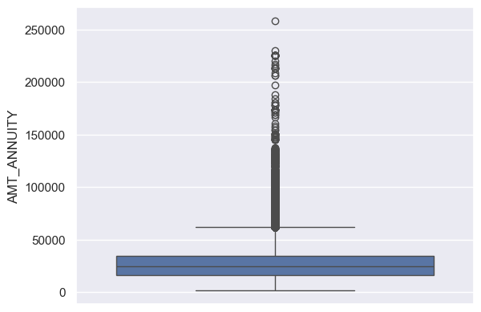

```python
sns.boxplot(application_data['AMT_ANNUITY'])
```

As we can see both description and boxplot visualization there are high number of outliers , so we can fill the Nan values with median

```python
application_data['AMT_ANNUITY'].fillna(application_data['AMT_ANNUITY'].median(),inplace=True)
```

```python
#pd.set_option("display.max_rows",None)
# displaying only columns having null values which is greater than 0
Null_columns = application_data.count()/len(application_data)
Null_columns = (1- Null_columns)*100
Null_columns[Null_columns>0].sort_values()
```

```
AMT_GOODS_PRICE     0.090403
NAME_TYPE_SUITE     0.420148
OCCUPATION_TYPE    31.345545
dtype: float64
```

### 6. AMT_GOODS_PRICE -- Numerical Variable

```python
application_data[['AMT_GOODS_PRICE']]
```

|  | AMT_GOODS_PRICE |
| --- | --- |
| 0 | 351000.0 |
| 1 | 1129500.0 |
| 2 | 135000.0 |
| 3 | 297000.0 |
| 4 | 513000.0 |
| ... | ... |
| 307506 | 225000.0 |
| 307507 | 225000.0 |
| 307508 | 585000.0 |
| 307509 | 319500.0 |
| 307510 | 675000.0 |

307511 rows × 1 columns

```python
application_data['AMT_GOODS_PRICE'].describe()
```

```
count    3.072330e+05
mean     5.383962e+05
std      3.694465e+05
min      4.050000e+04
25%      2.385000e+05
50%      4.500000e+05
75%      6.795000e+05
max      4.050000e+06
Name: AMT_GOODS_PRICE, dtype: float64
```

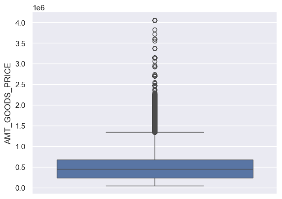

```python
sns.boxplot(application_data['AMT_GOODS_PRICE'])
```

As we can see both description and boxplot visualization there are high number of outliers , so we can fill the Nan values with median

```python
application_data['AMT_GOODS_PRICE'].fillna(application_data['AMT_GOODS_PRICE'].median(),inplace=True)
```

```python
#pd.set_option("display.max_rows",None)
# displaying only columns having null values which is greater than 0
Null_columns = application_data.count()/len(application_data)
Null_columns = (1- Null_columns)*100
Null_columns[Null_columns>0].sort_values()
```

```
NAME_TYPE_SUITE     0.420148
OCCUPATION_TYPE    31.345545
dtype: float64
```

### 7. NAME_TYPE_SUITE -- Categorical Variable

```python
application_data[['NAME_TYPE_SUITE']]
```

|  | NAME_TYPE_SUITE |
| --- | --- |
| 0 | Unaccompanied |
| 1 | Family |
| 2 | Unaccompanied |
| 3 | Unaccompanied |
| 4 | Unaccompanied |
| ... | ... |
| 307506 | Unaccompanied |
| 307507 | Unaccompanied |
| 307508 | Unaccompanied |
| 307509 | Unaccompanied |
| 307510 | Unaccompanied |

307511 rows × 1 columns

```python
application_data['NAME_TYPE_SUITE'].value_counts()
```

```
NAME_TYPE_SUITE
Unaccompanied      248526
Family              40149
Spouse, partner     11370
Children             3267
Other_B              1770
Other_A               866
Group of people       271
Name: count, dtype: int64
```

```python
# Most occcured
application_data['NAME_TYPE_SUITE'].mode()[0]
```

```
'Unaccompanied'
```

```python
# since ita an categorical variable flling NaN values with mode
application_data['NAME_TYPE_SUITE'].fillna(application_data['NAME_TYPE_SUITE'].mode()[0],inplace=True)
```

### 8. OCCUPATION_TYPE -- Categorical Variable

```python
#pd.set_option("display.max_rows",None)
# displaying only columns having null values which is greater than 0
Null_columns = application_data.count()/len(application_data)
Null_columns = (1- Null_columns)*100
Null_columns[Null_columns>0].sort_values()
```

```
OCCUPATION_TYPE    31.345545
dtype: float64
```

```python
application_data['OCCUPATION_TYPE'].value_counts()
```

```
OCCUPATION_TYPE
Laborers                 55186
Sales staff              32102
Core staff               27570
Managers                 21371
Drivers                  18603
High skill tech staff    11380
Accountants               9813
Medicine staff            8537
Security staff            6721
Cooking staff             5946
Cleaning staff            4653
Private service staff     2652
Low-skill Laborers        2093
Waiters/barmen staff      1348
Secretaries               1305
Realty agents              751
HR staff                   563
IT staff                   526
Name: count, dtype: int64
```

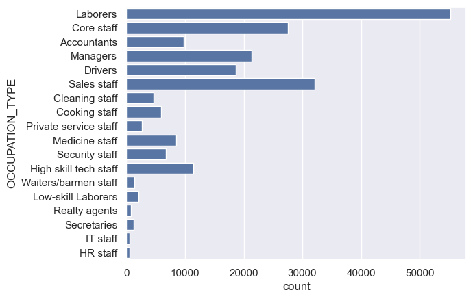

```python
# As we can see OCCUPATION_TYPE has 31 % and most of them are laboerers it will not be good approach to fill missing values with mode of that column
sns.countplot(application_data['OCCUPATION_TYPE'])
```

```python
# Lets fill the missing values with others as it will good for the analysis
application_data['OCCUPATION_TYPE'].fillna('Others',inplace=True)
```

```python
application_data.head()
```

|  | SK_ID_CURR | TARGET | NAME_CONTRACT_TYPE | CODE_GENDER | FLAG_OWN_CAR | FLAG_OWN_REALTY | CNT_CHILDREN | AMT_INCOME_TOTAL | AMT_CREDIT | AMT_ANNUITY | AMT_GOODS_PRICE | NAME_TYPE_SUITE | NAME_INCOME_TYPE | NAME_EDUCATION_TYPE | NAME_FAMILY_STATUS | NAME_HOUSING_TYPE | REGION_POPULATION_RELATIVE | DAYS_BIRTH | DAYS_EMPLOYED | DAYS_REGISTRATION | DAYS_ID_PUBLISH | FLAG_MOBIL | FLAG_EMP_PHONE | FLAG_WORK_PHONE | FLAG_CONT_MOBILE | FLAG_PHONE | FLAG_EMAIL | OCCUPATION_TYPE | CNT_FAM_MEMBERS | … |
| --- | --- | --- | --- | --- | --- | --- | --- | --- | --- | --- | --- | --- | --- | --- | --- | --- | --- | --- | --- | --- | --- | --- | --- | --- | --- | --- | --- | --- | --- | --- |
| 0 | 100002 | 1 | Cash loans | M | N | Y | 0 | 202500.0 | 406597.5 | 24700.5 | 351000.0 | Unaccompanied | Working | Secondary / secondary special | Single / not married | House / apartment | 0.018801 | -9461 | -637 | -3648.0 | -2120 | 1 | 1 | 0 | 1 | 1 | 0 | Laborers | 1 | … |
| 1 | 100003 | 0 | Cash loans | F | N | N | 0 | 270000.0 | 1293502.5 | 35698.5 | 1129500.0 | Family | State servant | Higher education | Married | House / apartment | 0.003541 | -16765 | -1188 | -1186.0 | -291 | 1 | 1 | 0 | 1 | 1 | 0 | Core staff | 2 | … |
| 2 | 100004 | 0 | Revolving loans | M | Y | Y | 0 | 67500.0 | 135000.0 | 6750.0 | 135000.0 | Unaccompanied | Working | Secondary / secondary special | Single / not married | House / apartment | 0.010032 | -19046 | -225 | -4260.0 | -2531 | 1 | 1 | 1 | 1 | 1 | 0 | Laborers | 1 | … |
| 3 | 100006 | 0 | Cash loans | F | N | Y | 0 | 135000.0 | 312682.5 | 29686.5 | 297000.0 | Unaccompanied | Working | Secondary / secondary special | Civil marriage | House / apartment | 0.008019 | -19005 | -3039 | -9833.0 | -2437 | 1 | 1 | 0 | 1 | 0 | 0 | Laborers | 2 | … |
| 4 | 100007 | 0 | Cash loans | M | N | Y | 0 | 121500.0 | 513000.0 | 21865.5 | 513000.0 | Unaccompanied | Working | Secondary / secondary special | Single / not married | House / apartment | 0.028663 | -19932 | -3038 | -4311.0 | -3458 | 1 | 1 | 0 | 1 | 0 | 0 | Core staff | 1 | … |

There are some more anomalies in data i.e. Days columns seems to be negative values and days cannot be in negative to need to change it into abs then we can standardise day into Year

```python
for col in application_data:
    if col.startswith("DAYS"):
        print(col)
```

```
DAYS_BIRTH
DAYS_EMPLOYED
DAYS_REGISTRATION
DAYS_ID_PUBLISH
```

```python
# now leats chage data type of DAYS_REGISTRATION and DAYS_LAST_PHONE_CHANGE float to integer
application_data['YEAR_REGISTRATION'] = application_data['DAYS_REGISTRATION'].astype(int)
```

```python
application_data['DAYS_BIRTH'] = application_data['DAYS_BIRTH'].abs()
application_data['DAYS_EMPLOYED'] = application_data['DAYS_EMPLOYED'].abs()
application_data['YEAR_REGISTRATION'] = application_data['YEAR_REGISTRATION'].abs()
application_data['DAYS_ID_PUBLISH'] = application_data['DAYS_ID_PUBLISH'].abs()
```

Lets add new column to change the day_birth as Age and DAYS_EMPLOYED, DAYS_REGISTRATION, DAYS_ID_PUBLISH to Number of Years

```python
application_data['AGE'] = application_data['DAYS_BIRTH']//365
application_data['YEAR_EMPLOYED'] = application_data['DAYS_EMPLOYED']//365
application_data['YEAR_REGISTRATION'] = application_data['YEAR_REGISTRATION']//365
application_data['YEAR_ID_PUBLISH'] = application_data['DAYS_ID_PUBLISH']//365
```

### Note: All days column are now considered as number of years

Lets Drop all Days Columns

```python
application_data.drop(columns = "DAYS_BIRTH",axis=1,inplace=True)
application_data.drop(columns = "DAYS_EMPLOYED",axis=1,inplace=True)
application_data.drop(columns = "DAYS_REGISTRATION",axis=1,inplace=True)
application_data.drop(columns = "DAYS_ID_PUBLISH",axis=1,inplace=True)
```

```python
application_data.shape
```

```
(307511, 73)
```

```python
application_data['NAME_EDUCATION_TYPE'].unique()
```

```
array(['Secondary / secondary special', 'Higher education',
       'Incomplete higher', 'Lower secondary', 'Academic degree'],
      dtype=object)
```

```python
application_data['NAME_FAMILY_STATUS'].unique()
```

```
array(['Single / not married', 'Married', 'Civil marriage', 'Widow',
       'Separated', 'Unknown'], dtype=object)
```

```python
application_data['NAME_HOUSING_TYPE'].unique()
```

```
array(['House / apartment', 'Rented apartment', 'With parents',
       'Municipal apartment', 'Office apartment', 'Co-op apartment'],
      dtype=object)
```

```python
application_data['ORGANIZATION_TYPE'].unique()
```

```
array(['Business Entity Type 3', 'School', 'Government', 'Religion',
       'Other', 'XNA', 'Electricity', 'Medicine',
       'Business Entity Type 2', 'Self-employed', 'Transport: type 2',
       'Construction', 'Housing', 'Kindergarten', 'Trade: type 7',
       'Industry: type 11', 'Military', 'Services', 'Security Ministries',
       'Transport: type 4', 'Industry: type 1', 'Emergency', 'Security',
       'Trade: type 2', 'University', 'Transport: type 3', 'Police',
       'Business Entity Type 1', 'Postal', 'Industry: type 4',
       'Agriculture', 'Restaurant', 'Culture', 'Hotel',
       'Industry: type 7', 'Trade: type 3', 'Industry: type 3', 'Bank',
       'Industry: type 9', 'Insurance', 'Trade: type 6',
       'Industry: type 2', 'Transport: type 1', 'Industry: type 12',
       'Mobile', 'Trade: type 1', 'Industry: type 5', 'Industry: type 10',
       'Legal Services', 'Advertising', 'Trade: type 5', 'Cleaning',
       'Industry: type 13', 'Trade: type 4', 'Telecom',
       'Industry: type 8', 'Realtor', 'Industry: type 6'], dtype=object)
```

As we can see above NAME_EDUCATION_TYPE has education Secondary / secondary special we can give it to one number Secondary , NAME_FAMILY_STATUS has Single / not married we can give Single and NAME_HOUSING_TYPE has House / apartment we can one name as House

```python
application_data['NAME_EDUCATION_TYPE'].replace("Secondary / secondary special","Secondary",inplace=True)
```

```python
application_data[['NAME_EDUCATION_TYPE']]
```

|  | NAME_EDUCATION_TYPE |
| --- | --- |
| 0 | Secondary |
| 1 | Higher education |
| 2 | Secondary |
| 3 | Secondary |
| 4 | Secondary |
| ... | ... |
| 307506 | Secondary |
| 307507 | Secondary |
| 307508 | Higher education |
| 307509 | Secondary |
| 307510 | Higher education |

307511 rows × 1 columns

```python
application_data['NAME_FAMILY_STATUS'].replace("Single / not married","Single",inplace=True)
application_data['NAME_HOUSING_TYPE'].replace("House / apartment","House",inplace=True)
```

```python
application_data.head()
```

|  | SK_ID_CURR | TARGET | NAME_CONTRACT_TYPE | CODE_GENDER | FLAG_OWN_CAR | FLAG_OWN_REALTY | CNT_CHILDREN | AMT_INCOME_TOTAL | AMT_CREDIT | AMT_ANNUITY | AMT_GOODS_PRICE | NAME_TYPE_SUITE | NAME_INCOME_TYPE | NAME_EDUCATION_TYPE | NAME_FAMILY_STATUS | NAME_HOUSING_TYPE | REGION_POPULATION_RELATIVE | FLAG_MOBIL | FLAG_EMP_PHONE | FLAG_WORK_PHONE | FLAG_CONT_MOBILE | FLAG_PHONE | FLAG_EMAIL | OCCUPATION_TYPE | CNT_FAM_MEMBERS | REGION_RATING_CLIENT | REGION_RATING_CLIENT_W_CITY | WEEKDAY_APPR_PROCESS_START | HOUR_APPR_PROCESS_START | … |
| --- | --- | --- | --- | --- | --- | --- | --- | --- | --- | --- | --- | --- | --- | --- | --- | --- | --- | --- | --- | --- | --- | --- | --- | --- | --- | --- | --- | --- | --- | --- |
| 0 | 100002 | 1 | Cash loans | M | N | Y | 0 | 202500.0 | 406597.5 | 24700.5 | 351000.0 | Unaccompanied | Working | Secondary | Single | House | 0.018801 | 1 | 1 | 0 | 1 | 1 | 0 | Laborers | 1 | 2 | 2 | WEDNESDAY | 10 | … |
| 1 | 100003 | 0 | Cash loans | F | N | N | 0 | 270000.0 | 1293502.5 | 35698.5 | 1129500.0 | Family | State servant | Higher education | Married | House | 0.003541 | 1 | 1 | 0 | 1 | 1 | 0 | Core staff | 2 | 1 | 1 | MONDAY | 11 | … |
| 2 | 100004 | 0 | Revolving loans | M | Y | Y | 0 | 67500.0 | 135000.0 | 6750.0 | 135000.0 | Unaccompanied | Working | Secondary | Single | House | 0.010032 | 1 | 1 | 1 | 1 | 1 | 0 | Laborers | 1 | 2 | 2 | MONDAY | 9 | … |
| 3 | 100006 | 0 | Cash loans | F | N | Y | 0 | 135000.0 | 312682.5 | 29686.5 | 297000.0 | Unaccompanied | Working | Secondary | Civil marriage | House | 0.008019 | 1 | 1 | 0 | 1 | 0 | 0 | Laborers | 2 | 2 | 2 | WEDNESDAY | 17 | … |
| 4 | 100007 | 0 | Cash loans | M | N | Y | 0 | 121500.0 | 513000.0 | 21865.5 | 513000.0 | Unaccompanied | Working | Secondary | Single | House | 0.028663 | 1 | 1 | 0 | 1 | 0 | 0 | Core staff | 1 | 2 | 2 | THURSDAY | 11 | … |

```python
application_data[application_data['ORGANIZATION_TYPE'] == 'XNA']
```

|  | SK_ID_CURR | TARGET | NAME_CONTRACT_TYPE | CODE_GENDER | FLAG_OWN_CAR | FLAG_OWN_REALTY | CNT_CHILDREN | AMT_INCOME_TOTAL | AMT_CREDIT | AMT_ANNUITY | AMT_GOODS_PRICE | NAME_TYPE_SUITE | NAME_INCOME_TYPE | NAME_EDUCATION_TYPE | NAME_FAMILY_STATUS | NAME_HOUSING_TYPE | REGION_POPULATION_RELATIVE | FLAG_MOBIL | FLAG_EMP_PHONE | FLAG_WORK_PHONE | FLAG_CONT_MOBILE | FLAG_PHONE | FLAG_EMAIL | OCCUPATION_TYPE | CNT_FAM_MEMBERS | REGION_RATING_CLIENT | REGION_RATING_CLIENT_W_CITY | WEEKDAY_APPR_PROCESS_START | HOUR_APPR_PROCESS_START | … |
| --- | --- | --- | --- | --- | --- | --- | --- | --- | --- | --- | --- | --- | --- | --- | --- | --- | --- | --- | --- | --- | --- | --- | --- | --- | --- | --- | --- | --- | --- | --- |
| 8 | 100011 | 0 | Cash loans | F | N | Y | 0 | 112500.000 | 1019610.0 | 33826.5 | 913500.0 | Children | Pensioner | Secondary | Married | House | 0.018634 | 1 | 0 | 0 | 1 | 0 | 0 | Others | 2 | 2 | 2 | WEDNESDAY | 14 | … |
| 11 | 100015 | 0 | Cash loans | F | N | Y | 0 | 38419.155 | 148365.0 | 10678.5 | 135000.0 | Children | Pensioner | Secondary | Married | House | 0.015221 | 1 | 0 | 0 | 1 | 1 | 0 | Others | 2 | 2 | 2 | FRIDAY | 7 | … |
| 23 | 100027 | 0 | Cash loans | F | N | Y | 0 | 83250.000 | 239850.0 | 23850.0 | 225000.0 | Unaccompanied | Pensioner | Secondary | Married | House | 0.006296 | 1 | 0 | 0 | 1 | 1 | 0 | Others | 2 | 3 | 3 | FRIDAY | 12 | … |
| 38 | 100045 | 0 | Cash loans | F | N | Y | 0 | 99000.000 | 247275.0 | 17338.5 | 225000.0 | Unaccompanied | Pensioner | Secondary | Married | House | 0.006207 | 1 | 0 | 0 | 1 | 1 | 0 | Others | 2 | 2 | 2 | FRIDAY | 11 | … |
| 43 | 100050 | 0 | Cash loans | F | N | Y | 0 | 108000.000 | 746280.0 | 42970.5 | 675000.0 | Unaccompanied | Pensioner | Higher education | Single | House | 0.010966 | 1 | 0 | 0 | 1 | 0 | 0 | Others | 1 | 2 | 2 | WEDNESDAY | 9 | … |
| ... | ... | ... | ... | ... | ... | ... | ... | ... | ... | ... | ... | ... | ... | ... | ... | ... | ... | ... | ... | ... | ... | ... | ... | ... | ... | ... | ... | ... | ... | … |
| 307469 | 456209 | 0 | Cash loans | F | N | Y | 0 | 202500.000 | 703728.0 | 29943.0 | 607500.0 | Unaccompanied | Pensioner | Secondary | Single | House | 0.031329 | 1 | 0 | 0 | 1 | 0 | 0 | Others | 1 | 2 | 2 | MONDAY | 15 | … |
| 307483 | 456227 | 0 | Cash loans | F | N | Y | 0 | 99000.000 | 247275.0 | 16479.0 | 225000.0 | Unaccompanied | Pensioner | Secondary | Separated | House | 0.007330 | 1 | 0 | 0 | 1 | 0 | 0 | Others | 1 | 2 | 2 | MONDAY | 12 | … |
| 307487 | 456231 | 0 | Cash loans | M | N | Y | 0 | 117000.000 | 1071909.0 | 31473.0 | 936000.0 | Unaccompanied | Pensioner | Secondary | Married | House | 0.010147 | 1 | 0 | 0 | 1 | 0 | 0 | Others | 2 | 2 | 2 | WEDNESDAY | 10 | … |
| 307505 | 456249 | 0 | Cash loans | F | N | Y | 0 | 112500.000 | 225000.0 | 22050.0 | 225000.0 | Unaccompanied | Pensioner | Secondary | Single | House | 0.022800 | 1 | 0 | 0 | 1 | 1 | 0 | Others | 1 | 2 | 2 | MONDAY | 15 | … |
| 307507 | 456252 | 0 | Cash loans | F | N | Y | 0 | 72000.000 | 269550.0 | 12001.5 | 225000.0 | Unaccompanied | Pensioner | Secondary | Widow | House | 0.025164 | 1 | 0 | 0 | 1 | 1 | 0 | Others | 1 | 2 | 2 | MONDAY | 8 | … |

55374 rows × 73 columns

As seen above data I have seen that NAME_INCOME_TYPE who are pensioner there ORGANIZATION_TYEP is XNA lets make another organization type as Retired as well

```python
application_data['ORGANIZATION_TYPE'].replace("XNA",'Retired', inplace=True)
```

```python
application_data['ORGANIZATION_TYPE'].isnull().sum()
```

```
0
```

There in Flag Documents Columns Which tells Us how many Documnets client submitted lets sum up all the columns and put it in a one columns i.e. All_Flag_document and we drop all the flag_document columns

```python
for col in application_data:
    if col.startswith("FLAG_DOCUMENT"):
        print(col)
```

```
FLAG_DOCUMENT_2
FLAG_DOCUMENT_3
FLAG_DOCUMENT_4
FLAG_DOCUMENT_5
FLAG_DOCUMENT_6
FLAG_DOCUMENT_7
FLAG_DOCUMENT_8
FLAG_DOCUMENT_9
FLAG_DOCUMENT_10
FLAG_DOCUMENT_11
FLAG_DOCUMENT_12
FLAG_DOCUMENT_13
FLAG_DOCUMENT_14
FLAG_DOCUMENT_15
FLAG_DOCUMENT_16
FLAG_DOCUMENT_17
FLAG_DOCUMENT_18
FLAG_DOCUMENT_19
FLAG_DOCUMENT_20
FLAG_DOCUMENT_21
```

```python
All_Document = ["FLAG_DOCUMENT_2", "FLAG_DOCUMENT_3","FLAG_DOCUMENT_4","FLAG_DOCUMENT_5","FLAG_DOCUMENT_6","FLAG_DOCUMENT_7","FLAG_DOCUMENT_8","FLAG_DOCUMENT_9","FLAG_DOCUMENT_10",
"FLAG_DOCUMENT_11","FLAG_DOCUMENT_12","FLAG_DOCUMENT_13","FLAG_DOCUMENT_14","FLAG_DOCUMENT_15","FLAG_DOCUMENT_16","FLAG_DOCUMENT_17","FLAG_DOCUMENT_18",
"FLAG_DOCUMENT_19","FLAG_DOCUMENT_20","FLAG_DOCUMENT_21"]
```

```python
application_data['All_Flag_document'] = application_data[All_Document].sum(axis= 1)
```

```python
application_data.drop(All_Document, axis=1,inplace = True)
```

```python
application_data.shape
```

```
(307511, 54)
```

```python
application_data.head()
```

|  | SK_ID_CURR | TARGET | NAME_CONTRACT_TYPE | CODE_GENDER | FLAG_OWN_CAR | FLAG_OWN_REALTY | CNT_CHILDREN | AMT_INCOME_TOTAL | AMT_CREDIT | AMT_ANNUITY | AMT_GOODS_PRICE | NAME_TYPE_SUITE | NAME_INCOME_TYPE | NAME_EDUCATION_TYPE | NAME_FAMILY_STATUS | NAME_HOUSING_TYPE | REGION_POPULATION_RELATIVE | FLAG_MOBIL | FLAG_EMP_PHONE | FLAG_WORK_PHONE | FLAG_CONT_MOBILE | FLAG_PHONE | FLAG_EMAIL | OCCUPATION_TYPE | CNT_FAM_MEMBERS | REGION_RATING_CLIENT | REGION_RATING_CLIENT_W_CITY | WEEKDAY_APPR_PROCESS_START | HOUR_APPR_PROCESS_START | … |
| --- | --- | --- | --- | --- | --- | --- | --- | --- | --- | --- | --- | --- | --- | --- | --- | --- | --- | --- | --- | --- | --- | --- | --- | --- | --- | --- | --- | --- | --- | --- |
| 0 | 100002 | 1 | Cash loans | M | N | Y | 0 | 202500.0 | 406597.5 | 24700.5 | 351000.0 | Unaccompanied | Working | Secondary | Single | House | 0.018801 | 1 | 1 | 0 | 1 | 1 | 0 | Laborers | 1 | 2 | 2 | WEDNESDAY | 10 | … |
| 1 | 100003 | 0 | Cash loans | F | N | N | 0 | 270000.0 | 1293502.5 | 35698.5 | 1129500.0 | Family | State servant | Higher education | Married | House | 0.003541 | 1 | 1 | 0 | 1 | 1 | 0 | Core staff | 2 | 1 | 1 | MONDAY | 11 | … |
| 2 | 100004 | 0 | Revolving loans | M | Y | Y | 0 | 67500.0 | 135000.0 | 6750.0 | 135000.0 | Unaccompanied | Working | Secondary | Single | House | 0.010032 | 1 | 1 | 1 | 1 | 1 | 0 | Laborers | 1 | 2 | 2 | MONDAY | 9 | … |
| 3 | 100006 | 0 | Cash loans | F | N | Y | 0 | 135000.0 | 312682.5 | 29686.5 | 297000.0 | Unaccompanied | Working | Secondary | Civil marriage | House | 0.008019 | 1 | 1 | 0 | 1 | 0 | 0 | Laborers | 2 | 2 | 2 | WEDNESDAY | 17 | … |
| 4 | 100007 | 0 | Cash loans | M | N | Y | 0 | 121500.0 | 513000.0 | 21865.5 | 513000.0 | Unaccompanied | Working | Secondary | Single | House | 0.028663 | 1 | 1 | 0 | 1 | 0 | 0 | Core staff | 1 | 2 | 2 | THURSDAY | 11 | … |

#### Segragatting Numericqal and Categorical Columns

```python
Cat_col = list(set(application_data.columns) - set(application_data.describe().columns))
Num_col = application_data.describe().columns
```

```python
application_data[Cat_col].head()
```

|  | OCCUPATION_TYPE | NAME_EDUCATION_TYPE | CODE_GENDER | NAME_TYPE_SUITE | FLAG_OWN_REALTY | NAME_HOUSING_TYPE | WEEKDAY_APPR_PROCESS_START | ORGANIZATION_TYPE | NAME_INCOME_TYPE | NAME_FAMILY_STATUS | FLAG_OWN_CAR | NAME_CONTRACT_TYPE |
| --- | --- | --- | --- | --- | --- | --- | --- | --- | --- | --- | --- | --- |
| 0 | Laborers | Secondary | M | Unaccompanied | Y | House | WEDNESDAY | Business Entity Type 3 | Working | Single | N | Cash loans |
| 1 | Core staff | Higher education | F | Family | N | House | MONDAY | School | State servant | Married | N | Cash loans |
| 2 | Laborers | Secondary | M | Unaccompanied | Y | House | MONDAY | Government | Working | Single | Y | Revolving loans |
| 3 | Laborers | Secondary | F | Unaccompanied | Y | House | WEDNESDAY | Business Entity Type 3 | Working | Civil marriage | N | Cash loans |
| 4 | Core staff | Secondary | M | Unaccompanied | Y | House | THURSDAY | Religion | Working | Single | N | Cash loans |

```python
application_data[Num_col].head()
```

|  | SK_ID_CURR | TARGET | CNT_CHILDREN | AMT_INCOME_TOTAL | AMT_CREDIT | AMT_ANNUITY | AMT_GOODS_PRICE | REGION_POPULATION_RELATIVE | FLAG_MOBIL | FLAG_EMP_PHONE | FLAG_WORK_PHONE | FLAG_CONT_MOBILE | FLAG_PHONE | FLAG_EMAIL | CNT_FAM_MEMBERS | REGION_RATING_CLIENT | REGION_RATING_CLIENT_W_CITY | HOUR_APPR_PROCESS_START | REG_REGION_NOT_LIVE_REGION | REG_REGION_NOT_WORK_REGION | LIVE_REGION_NOT_WORK_REGION | REG_CITY_NOT_LIVE_CITY | REG_CITY_NOT_WORK_CITY | LIVE_CITY_NOT_WORK_CITY | EXT_SOURCE_2 | EXT_SOURCE_3 | OBS_30_CNT_SOCIAL_CIRCLE | DEF_30_CNT_SOCIAL_CIRCLE | OBS_60_CNT_SOCIAL_CIRCLE | … |
| --- | --- | --- | --- | --- | --- | --- | --- | --- | --- | --- | --- | --- | --- | --- | --- | --- | --- | --- | --- | --- | --- | --- | --- | --- | --- | --- | --- | --- | --- | --- |
| 0 | 100002 | 1 | 0 | 202500.0 | 406597.5 | 24700.5 | 351000.0 | 0.018801 | 1 | 1 | 0 | 1 | 1 | 0 | 1 | 2 | 2 | 10 | 0 | 0 | 0 | 0 | 0 | 0 | 0.262949 | 0.139376 | 2.0 | 2.0 | 2.0 | … |
| 1 | 100003 | 0 | 0 | 270000.0 | 1293502.5 | 35698.5 | 1129500.0 | 0.003541 | 1 | 1 | 0 | 1 | 1 | 0 | 2 | 1 | 1 | 11 | 0 | 0 | 0 | 0 | 0 | 0 | 0.622246 | 0.535276 | 1.0 | 0.0 | 1.0 | … |
| 2 | 100004 | 0 | 0 | 67500.0 | 135000.0 | 6750.0 | 135000.0 | 0.010032 | 1 | 1 | 1 | 1 | 1 | 0 | 1 | 2 | 2 | 9 | 0 | 0 | 0 | 0 | 0 | 0 | 0.555912 | 0.729567 | 0.0 | 0.0 | 0.0 | … |
| 3 | 100006 | 0 | 0 | 135000.0 | 312682.5 | 29686.5 | 297000.0 | 0.008019 | 1 | 1 | 0 | 1 | 0 | 0 | 2 | 2 | 2 | 17 | 0 | 0 | 0 | 0 | 0 | 0 | 0.650442 | 0.535276 | 2.0 | 0.0 | 2.0 | … |
| 4 | 100007 | 0 | 0 | 121500.0 | 513000.0 | 21865.5 | 513000.0 | 0.028663 | 1 | 1 | 0 | 1 | 0 | 0 | 1 | 2 | 2 | 11 | 0 | 0 | 0 | 0 | 1 | 1 | 0.322738 | 0.535276 | 0.0 | 0.0 | 0.0 | … |

## Handling Outlier For Application Data

- AMT_INCOME_TOTAL
- AMT_CREDIT
- AMT_ANNUITY
- AMT_GOODS_PRICE
- EXT_SOURCE_2
- EXT_SOURCE_3
- AGE

## 1. AMT_INCOME_TOTAL

```python
application_data['AMT_INCOME_TOTAL'].describe()
```

```
count    3.075110e+05
mean     1.687979e+05
std      2.371231e+05
min      2.565000e+04
25%      1.125000e+05
50%      1.471500e+05
75%      2.025000e+05
max      1.170000e+08
Name: AMT_INCOME_TOTAL, dtype: float64
```

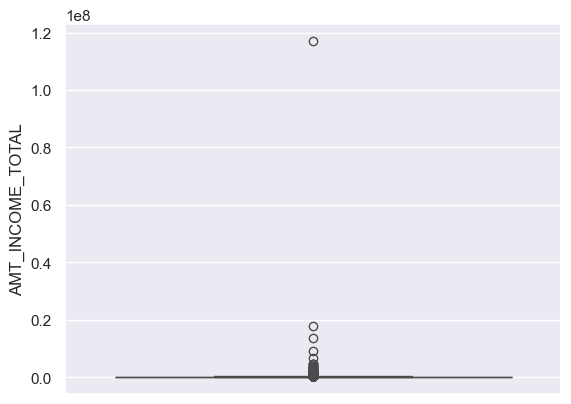

```python
sns.boxplot(application_data.AMT_INCOME_TOTAL)
```

```python
#print the quantile (0.5, 0.7, 0.9, 0.95 and 0.99) of Amt Income Total variable
application_data.AMT_INCOME_TOTAL.quantile([0.5,0.7,0.95,0.99])
```

```
0.50    147150.0
0.70    180000.0
0.95    337500.0
0.99    472500.0
Name: AMT_INCOME_TOTAL, dtype: float64
```

```python
application_data['AMT_INCOME_TOTAL'].max()
```

```
117000000.0
```

```python
application_data[application_data['AMT_INCOME_TOTAL'] == 117000000.0]
```

|  | SK_ID_CURR | TARGET | NAME_CONTRACT_TYPE | CODE_GENDER | FLAG_OWN_CAR | FLAG_OWN_REALTY | CNT_CHILDREN | AMT_INCOME_TOTAL | AMT_CREDIT | AMT_ANNUITY | AMT_GOODS_PRICE | NAME_TYPE_SUITE | NAME_INCOME_TYPE | NAME_EDUCATION_TYPE | NAME_FAMILY_STATUS | NAME_HOUSING_TYPE | REGION_POPULATION_RELATIVE | FLAG_MOBIL | FLAG_EMP_PHONE | FLAG_WORK_PHONE | FLAG_CONT_MOBILE | FLAG_PHONE | FLAG_EMAIL | OCCUPATION_TYPE | CNT_FAM_MEMBERS | REGION_RATING_CLIENT | REGION_RATING_CLIENT_W_CITY | WEEKDAY_APPR_PROCESS_START | HOUR_APPR_PROCESS_START | … |
| --- | --- | --- | --- | --- | --- | --- | --- | --- | --- | --- | --- | --- | --- | --- | --- | --- | --- | --- | --- | --- | --- | --- | --- | --- | --- | --- | --- | --- | --- | --- |
| 12840 | 114967 | 1 | Cash loans | F | N | Y | 1 | 117000000.0 | 562491.0 | 26194.5 | 454500.0 | Unaccompanied | Working | Secondary | Married | House | 0.010643 | 1 | 1 | 0 | 1 | 0 | 0 | Laborers | 3 | 2 | 2 | TUESDAY | 14 | … |

As we can see above the person income is 117000000.0 and have 2 years of employed where age is 34 this i think wont be possible where occuoation type is laboers definately this is an outlier. so we need to remove an outlier for amt_income_total

```python
Q1 = application_data['AMT_INCOME_TOTAL'].quantile(0.25)
Q3 = application_data['AMT_INCOME_TOTAL'].quantile(0.75)
IQR = Q3 - Q1
lower_range = Q1-1.5*IQR
higher_range = Q3+1.5*IQR
application_data = application_data[(application_data['AMT_INCOME_TOTAL'] > lower_range) & (application_data['AMT_INCOME_TOTAL'] < higher_range)]
```

```python
application_data.shape
```

```
(291686, 54)
```

```python
application_data.shape
```

```
(291686, 54)
```

## 2. AMT_CREDIT

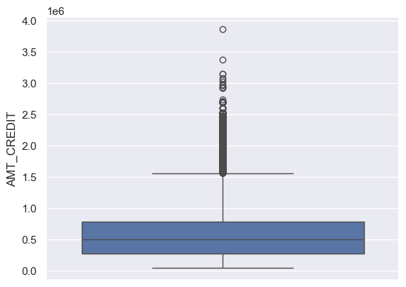

```python
sns.boxplot(application_data.AMT_CREDIT)
```

```python
Q1 = application_data['AMT_CREDIT'].quantile(0.25)
Q3 = application_data['AMT_CREDIT'].quantile(0.75)
IQR = Q3 - Q1
lower_range = Q1-1.5*IQR
higher_range = Q3+1.5*IQR
application_data = application_data[(application_data['AMT_CREDIT'] > lower_range) & (application_data['AMT_CREDIT'] < higher_range)]
```

```python
application_data.shape
```

```
(286024, 54)
```

## 2. AMT_ANNUITY

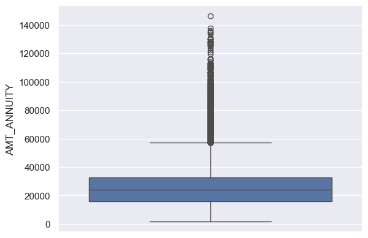

```python
sns.boxplot(application_data['AMT_ANNUITY'])
```

There are outliers in AMT_ANNUITY but we cannot drop these columns because amt annuity is the payment made by the client on the regular basis

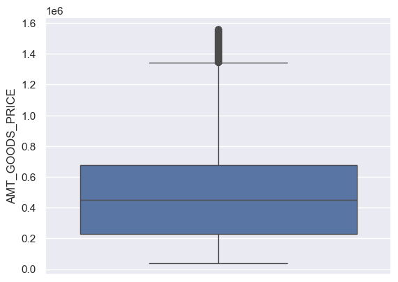

```python
sns.boxplot(application_data['AMT_GOODS_PRICE'])
```

There are outliers in AMT_GOODS_PRICE but we cannot drop these columns because AMT_GOODS_PRICE is the price of goods for which client has taken the loan

## 3. EXT_SOURCE_2

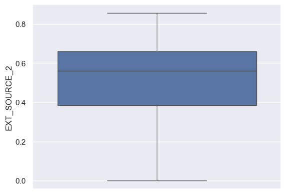

```python
sns.boxplot(application_data['EXT_SOURCE_2'])
```

There are not single putlier found in EXT_SOURCE_2 column

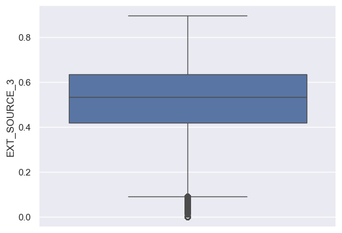

```python
sns.boxplot(application_data['EXT_SOURCE_3'])
```

```python
Q1 = application_data['EXT_SOURCE_3'].quantile(0.25)
Q3 = application_data['EXT_SOURCE_3'].quantile(0.75)
IQR = Q3 - Q1
lower_range = Q1-1.5*IQR
higher_range = Q3+1.5*IQR
application_data = application_data[(application_data['EXT_SOURCE_3'] > lower_range) & (application_data['EXT_SOURCE_3'] < higher_range)]
```

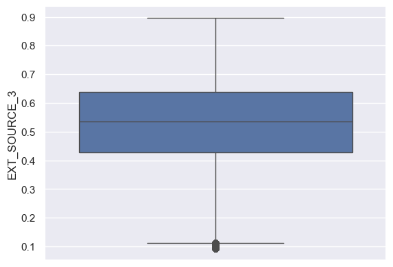

```python
sns.boxplot(application_data['EXT_SOURCE_3'])
```

```python
application_data.head()
```

|  | SK_ID_CURR | TARGET | NAME_CONTRACT_TYPE | CODE_GENDER | FLAG_OWN_CAR | FLAG_OWN_REALTY | CNT_CHILDREN | AMT_INCOME_TOTAL | AMT_CREDIT | AMT_ANNUITY | AMT_GOODS_PRICE | NAME_TYPE_SUITE | NAME_INCOME_TYPE | NAME_EDUCATION_TYPE | NAME_FAMILY_STATUS | NAME_HOUSING_TYPE | REGION_POPULATION_RELATIVE | FLAG_MOBIL | FLAG_EMP_PHONE | FLAG_WORK_PHONE | FLAG_CONT_MOBILE | FLAG_PHONE | FLAG_EMAIL | OCCUPATION_TYPE | CNT_FAM_MEMBERS | REGION_RATING_CLIENT | REGION_RATING_CLIENT_W_CITY | WEEKDAY_APPR_PROCESS_START | HOUR_APPR_PROCESS_START | … |
| --- | --- | --- | --- | --- | --- | --- | --- | --- | --- | --- | --- | --- | --- | --- | --- | --- | --- | --- | --- | --- | --- | --- | --- | --- | --- | --- | --- | --- | --- | --- |
| 0 | 100002 | 1 | Cash loans | M | N | Y | 0 | 202500.0 | 406597.5 | 24700.5 | 351000.0 | Unaccompanied | Working | Secondary | Single | House | 0.018801 | 1 | 1 | 0 | 1 | 1 | 0 | Laborers | 1 | 2 | 2 | WEDNESDAY | 10 | … |
| 1 | 100003 | 0 | Cash loans | F | N | N | 0 | 270000.0 | 1293502.5 | 35698.5 | 1129500.0 | Family | State servant | Higher education | Married | House | 0.003541 | 1 | 1 | 0 | 1 | 1 | 0 | Core staff | 2 | 1 | 1 | MONDAY | 11 | … |
| 2 | 100004 | 0 | Revolving loans | M | Y | Y | 0 | 67500.0 | 135000.0 | 6750.0 | 135000.0 | Unaccompanied | Working | Secondary | Single | House | 0.010032 | 1 | 1 | 1 | 1 | 1 | 0 | Laborers | 1 | 2 | 2 | MONDAY | 9 | … |
| 3 | 100006 | 0 | Cash loans | F | N | Y | 0 | 135000.0 | 312682.5 | 29686.5 | 297000.0 | Unaccompanied | Working | Secondary | Civil marriage | House | 0.008019 | 1 | 1 | 0 | 1 | 0 | 0 | Laborers | 2 | 2 | 2 | WEDNESDAY | 17 | … |
| 4 | 100007 | 0 | Cash loans | M | N | Y | 0 | 121500.0 | 513000.0 | 21865.5 | 513000.0 | Unaccompanied | Working | Secondary | Single | House | 0.028663 | 1 | 1 | 0 | 1 | 0 | 0 | Core staff | 1 | 2 | 2 | THURSDAY | 11 | … |

```python
application_data.shape
```

```
(281692, 54)
```

# Data Visualization

### Target column Analysis

#### As we can see below only 8.0 % of the people are the defaulters as compare to repayor's that is 92.0% this is an imbalanced data where we can see there only few defaulters

- 1 represents the defaulters who get difficulty to repay the loan
- 0 represents the repayer who was able to replay the loan

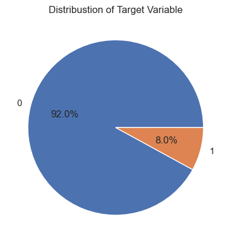

```python
plt.pie(application_data['TARGET'].value_counts(), labels= application_data['TARGET'].value_counts().index, autopct='%1.1f%%')
plt.title("Distribustion of Target Variable")
plt.show()
```

```python
Ratio = (application_data['TARGET']==0).sum() /(application_data['TARGET']== 1).sum()
Ratio
```

```
11.540266215554468
```

## 1. Age column

```python
application_data['Age'] = pd.cut(application_data.AGE,[0,10,20,30,40,50,60,70,80,90,100], labels=['0-10','10-20','20-30','30-40','40-50','50-60','60-70','70-80','80-90','90-100'])
#application_data.drop(columns='AGE',inplace=True,axis= 1)
```

```python
application_data.Age.value_counts()
```

```
Age
30-40     75076
40-50     66883
50-60     62511
20-30     49094
60-70     28127
10-20         1
0-10          0
70-80         0
80-90         0
90-100        0
Name: count, dtype: int64
```

## 2. Amt Income

```python
application_data['AMT_INCOME_TOTAL'].describe()
```

```
count    281692.000000
mean     151664.187576
std       61891.551436
min       25650.000000
25%      112500.000000
50%      135000.000000
75%      185863.500000
max      337050.000000
Name: AMT_INCOME_TOTAL, dtype: float64
```

```python
application_data['AMT_INCOME_GROUP'] = pd.cut(application_data['AMT_INCOME_TOTAL'],[25000, 30000, 40000, 50000, 60000, 70000, 80000, 90000, 100000, 200000, 300000, 400000], labels=['25k - 30k', '30k - 40k', '40k - 50k', '50k - 60k', '60k - 70k', '70k - 80k', '80k - 90k', '90k - 100k', '100k - 200k', '200k - 300k', '300k - 400k' ])
#application_data.drop(columns='AMT_INCOME_TOTAL', inplace=True, axis=1)
```

```python
application_data.AMT_INCOME_GROUP.value_counts()
```

```
AMT_INCOME_GROUP
100k - 200k    151617
200k - 300k     61073
80k - 90k       30147
60k - 70k       12733
300k - 400k      6133
70k - 80k        5841
90k - 100k       5674
50k - 60k        3995
40k - 50k        3522
30k - 40k         818
25k - 30k         139
Name: count, dtype: int64
```

## 2. Amt Credit

```python
application_data['AMT_CREDIT'].describe()
```

```
count    2.816920e+05
mean     5.536835e+05
std      3.418958e+05
min      4.500000e+04
25%      2.700000e+05
50%      4.950000e+05
75%      7.702920e+05
max      1.562076e+06
Name: AMT_CREDIT, dtype: float64
```

```python
application_data['AMT_CREDIT_GROUP'] = pd.cut(application_data['AMT_CREDIT'], [45000, 270000, 513531, 808650, 1200000, 1600000, 2000000, 2500000, 4050000], labels=['45k-270k', '270k-513.5k', '513.5k-808.65k', '808.65k-1.2M', '1.2M-1.6M', '1.6M-2M', '2M-2.5M', '2.5M-4.05M'])
#application_data.drop(columns= 'AMT_CREDIT', inplace=True, axis= 1)
```

```python
application_data.AMT_CREDIT_GROUP.value_counts()
```

```
AMT_CREDIT_GROUP
45k-270k          75968
513.5k-808.65k    73002
270k-513.5k       72055
808.65k-1.2M      43273
1.2M-1.6M         17170
1.6M-2M               0
2M-2.5M               0
2.5M-4.05M            0
Name: count, dtype: int64
```

### Done with the Data cleaning now analyzing the columns

## UNIVARIATE ANALYSIS

```python
def plotting(data, column):
    fig = plt.figure(figsize=(16,6))

    ax1 = plt.subplot(1,2,1)
    sns.countplot(data = data, palette='Set1',x = column, ax = ax1)
    plt.title('Plotting data for the column: '+ column)
    plt.xticks(rotation=90)
    ax1.set_yscale("log")


    ax2 = plt.subplot(1,2,2)
    sns.countplot(data = data, palette='Set1',x = column, hue= 'TARGET', ax = ax2) # hue is used to differentiate the target variable
    plt.title('Plotting data for the column: '+ column)
    plt.xticks(rotation=90)
    ax2.set_yscale("log")

    plt.tight_layout() # Or equivalently,  "plt.tight_layout()"

    plt.show()
```

```python
cat_col = list(set(application_data.columns) - set(application_data.describe().columns))
num_col = application_data.describe().columns
```

```python
cat_col
```

```
['OCCUPATION_TYPE',
 'NAME_EDUCATION_TYPE',
 'Age',
 'CODE_GENDER',
 'NAME_TYPE_SUITE',
 'FLAG_OWN_REALTY',
 'NAME_HOUSING_TYPE',
 'AMT_CREDIT_GROUP',
 'AMT_INCOME_GROUP',
 'WEEKDAY_APPR_PROCESS_START',
 'ORGANIZATION_TYPE',
 'NAME_INCOME_TYPE',
 'NAME_FAMILY_STATUS',
 'FLAG_OWN_CAR',
 'NAME_CONTRACT_TYPE']
```

## Plotting Categorical Columns

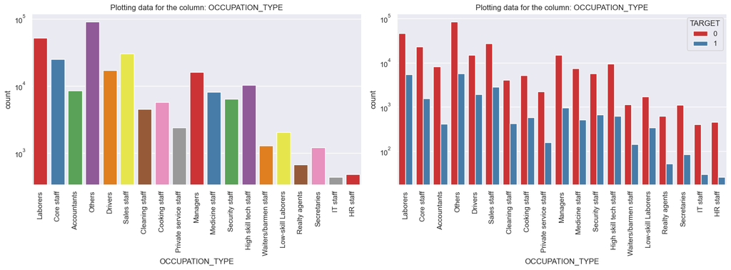

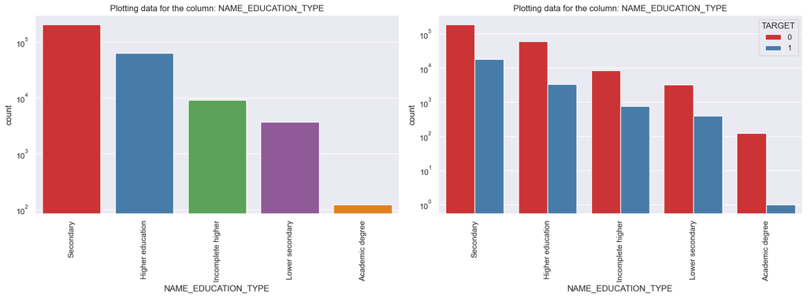

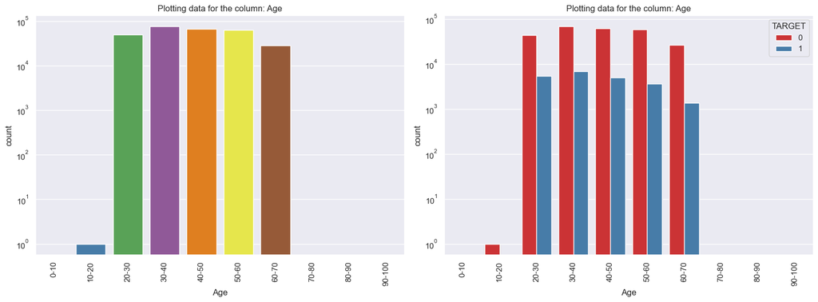

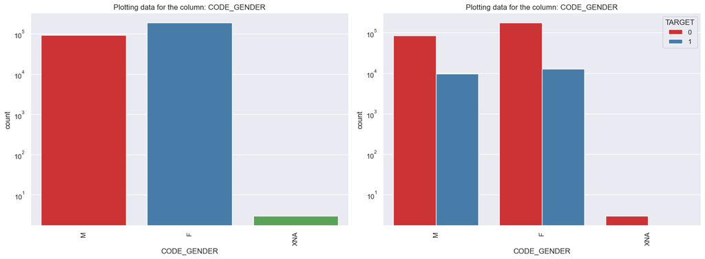

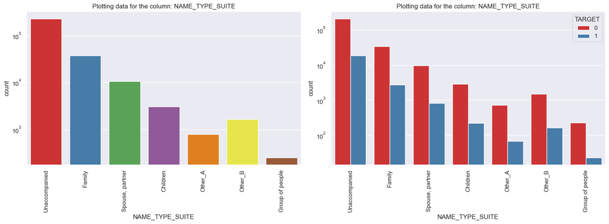

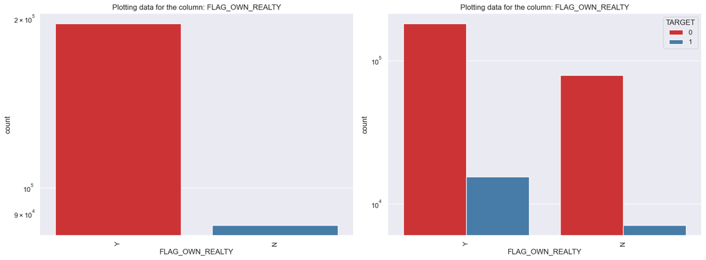

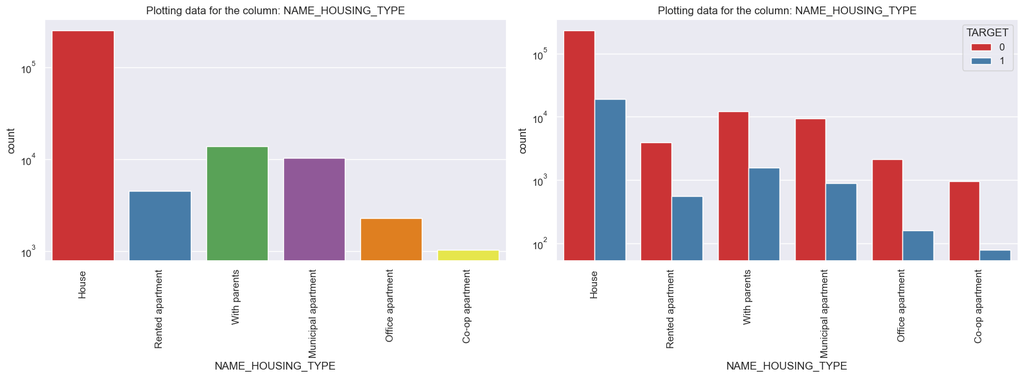

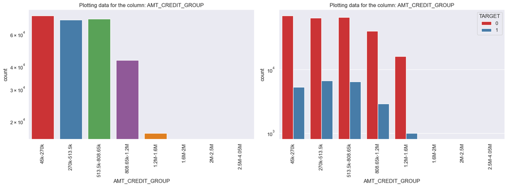

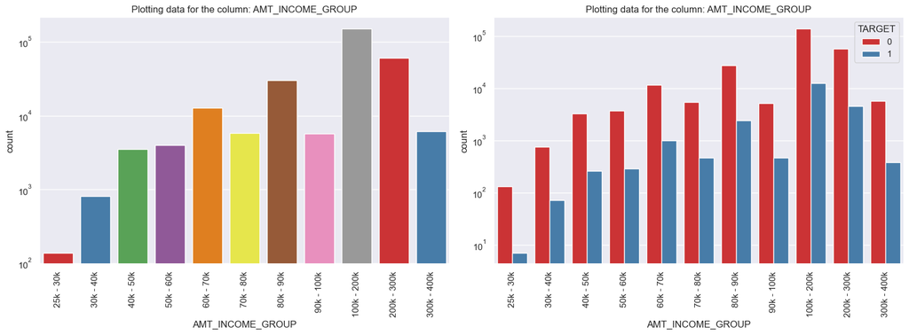

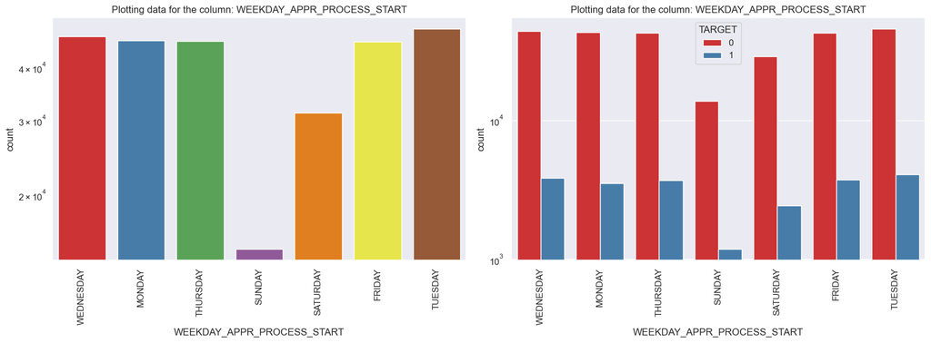

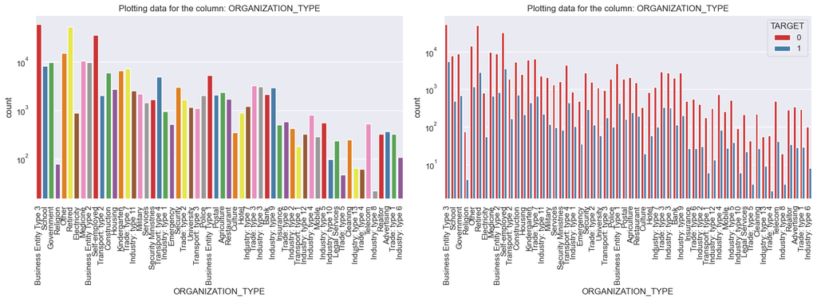

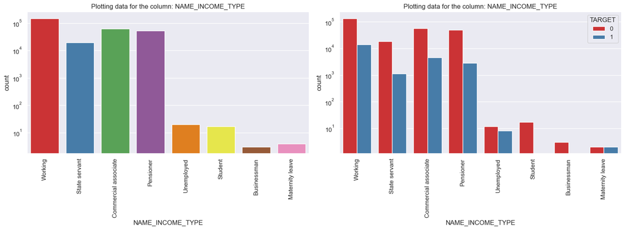

[3 more figures not shown]

```python
for column in cat_col:
    plotting(application_data, column)
    print('----------------------------------------------------------------------------------------------------------------------------------------------------------')
```

## Insights From Categorical column

#### client owns a house or flat

1. The majority of the client own a house.flat thta is just a double who dont owe a flat
2. As compare to target variable we see that there is no much difference between the owning the flat and loan defaulters it can seen that the people who dont owe a flat also considered as a defaulter

## 2. OCCUPATION TYPE

#### Client Occupation and loan defaulters

#### Count of the people taken loan

1. The majority of people who has tajken a loan comes under "laborers" , "Others" (These are the clients whose occupation is not mentioned in the data) ,"Core staff", "Sales Staff"
2. It and Hr Staff comes under small group who are taen the loan

## 3. AGE

#### Loan Defaulter

1. Majority of the people who are under 30- 40 has done loan default
2. As the age increses there are less chance to do the default in loan > 70 year of age

## 4. WEEkDAY_APP_PROCESS_START

#### Count of the people taken loan

1. As we can see mostly all weeks clients has taken the loan except sunday because mostly sunday are holidays

#### Loan Defaulter

1. As I cann see the plot with the default loan repay there nothing much we can see in the weekday_app_process_start column I can also drop this column from my analysis

## 5. AMT_CREDIT_GROUP

#### Count of the people taken loan

1. As we can see mostly of the people taken loan is between 45 k - 270k

## 6. Name_Housing_Type

#### Count of the people taken loan

1. the Majority of the people has taken loan who owns house, and leaving with parents

#### Loan Defaulter

1. People leaving in house and with parents are highst defaulters
2. The people leaving in co appartment rate are less dfaulters

## 7. Name_Contract_Type

#### Count of the people taken loan

1. Cash Loan are just double then the revolving loan

#### Loan Defaulter

1. We can see cliet taken revolving loan is more defaulter as revolving loan percentage is less than cash loan as well as cash loan ans revolving loan are both comes under defulater.

## 8. Name_Family_Status

#### Count of the people taken loan

1. Most of the people who has taken loan are married followed by single and civil marriage

#### Loan Defaulter

1. if we see civil marriage has the highest percent of not repayment with Widow the lowest.

## 9. NAME_INCOME_TYPE

#### Count of the people taken loan

1. Most of client for loans have income type as Working, followed by Commercial associate, Pensioner and State servant

#### Loan Defaulter

1. if we see the client who are on maternity leave has the highest possibility not to repay the loan, followed by unemployed.
2. Students and businessman are not done in default ratio these are group which safer to provide the loan.

## 10. FLAG_OWN_CAR

#### Count of the people taken loan

1. Clients who own a car are half in number of the clients who dont own a car.

#### Loan Defaulter

1. But based on the percentage of deault, there is no correlation between owning a car and loan repayment as in both cases the default percentage is almost same.

## 11. AMT_INCOME_GROUP

#### Count of the people taken loan

1. the mostly client income comes under 100k - 200k followed by 200k - 300k

#### Loan Defaulter

1. The client whoes income is between 100k to 300k is likely to do more defaults
2. the client whoes income is less than 30k is likely to do less defaults.

## 12. NAME_EDUCATION_TYPE

#### Count of the people taken loan

1. The most of the people are secondary educated followed by higher education very less number of academic degree holder

#### Loan Defaulter

1. lower secondary, secondar and incomplete higher are highest number of not repaying the loan

## 13. CODE_GENDER

#### Count of the people taken loan

1. As compare to male female has more number loans taken

#### Loan Defaulter

1. As we can see there male as comapare to female who has not repayed the loan

## 14. NAME_TYPE_SUTE

#### Count of the people taken loan

1. Majority client are unaccompanied while applying for the loan and the clients were with their families and less amount of them were accompanied by their spouse.
2. .

#### Loan Defaulter

1. ALL of them have the same default rate, therefore the people who accompany the client while applying for the loan does not play a big role in deciding whether he/she defaults the loan.n

## 15. FLAG_OWN_REALTY

### Count of the people taken loan

Loan Defaulter

Based on the data, there doesn’t appear to be a significant correlation between owning real estate and loan defalting.

## Plotting Numerical Columns

```python
num_col
```

```
Index(['SK_ID_CURR', 'TARGET', 'CNT_CHILDREN', 'AMT_INCOME_TOTAL',
       'AMT_CREDIT', 'AMT_ANNUITY', 'AMT_GOODS_PRICE',
       'REGION_POPULATION_RELATIVE', 'FLAG_MOBIL', 'FLAG_EMP_PHONE',
       'FLAG_WORK_PHONE', 'FLAG_CONT_MOBILE', 'FLAG_PHONE', 'FLAG_EMAIL',
       'CNT_FAM_MEMBERS', 'REGION_RATING_CLIENT',
       'REGION_RATING_CLIENT_W_CITY', 'HOUR_APPR_PROCESS_START',
       'REG_REGION_NOT_LIVE_REGION', 'REG_REGION_NOT_WORK_REGION',
       'LIVE_REGION_NOT_WORK_REGION', 'REG_CITY_NOT_LIVE_CITY',
       'REG_CITY_NOT_WORK_CITY', 'LIVE_CITY_NOT_WORK_CITY', 'EXT_SOURCE_2',
       'EXT_SOURCE_3', 'OBS_30_CNT_SOCIAL_CIRCLE', 'DEF_30_CNT_SOCIAL_CIRCLE',
       'OBS_60_CNT_SOCIAL_CIRCLE', 'DEF_60_CNT_SOCIAL_CIRCLE',
       'AMT_REQ_CREDIT_BUREAU_HOUR', 'AMT_REQ_CREDIT_BUREAU_DAY',
       'AMT_REQ_CREDIT_BUREAU_WEEK', 'AMT_REQ_CREDIT_BUREAU_MON',
       'AMT_REQ_CREDIT_BUREAU_QRT', 'AMT_REQ_CREDIT_BUREAU_YEAR',
       'YEAR_LAST_PHONE_CHANGE', 'YEAR_REGISTRATION', 'AGE', 'YEAR_EMPLOYED',
       'YEAR_ID_PUBLISH', 'All_Flag_document'],
      dtype='object')
```

```python
correlation = application_data[num_col].corr()
```

```python
correlation.TARGET.sort_values(ascending=True)
```

```
EXT_SOURCE_2                  -0.156071
EXT_SOURCE_3                  -0.140068
AGE                           -0.077633
YEAR_LAST_PHONE_CHANGE        -0.056615
YEAR_ID_PUBLISH               -0.050140
YEAR_EMPLOYED                 -0.048522
YEAR_REGISTRATION             -0.043160
REGION_POPULATION_RELATIVE    -0.032299
AMT_GOODS_PRICE               -0.026982
FLAG_PHONE                    -0.024581
HOUR_APPR_PROCESS_START       -0.023639
AMT_CREDIT                    -0.016544
AMT_REQ_CREDIT_BUREAU_MON     -0.014527
AMT_INCOME_TOTAL              -0.012079
AMT_REQ_CREDIT_BUREAU_QRT     -0.008763
AMT_REQ_CREDIT_BUREAU_WEEK    -0.002383
SK_ID_CURR                    -0.001632
FLAG_EMAIL                    -0.001489
AMT_REQ_CREDIT_BUREAU_HOUR    -0.000324
FLAG_CONT_MOBILE              -0.000271
FLAG_MOBIL                     0.000555
AMT_REQ_CREDIT_BUREAU_DAY      0.002053
AMT_ANNUITY                    0.002669
LIVE_REGION_NOT_WORK_REGION    0.005222
REG_REGION_NOT_LIVE_REGION     0.005793
OBS_60_CNT_SOCIAL_CIRCLE       0.008020
OBS_30_CNT_SOCIAL_CIRCLE       0.008181
REG_REGION_NOT_WORK_REGION     0.009107
AMT_REQ_CREDIT_BUREAU_YEAR     0.010842
CNT_FAM_MEMBERS                0.011666
All_Flag_document              0.018902
CNT_CHILDREN                   0.021147
FLAG_WORK_PHONE                0.027574
DEF_60_CNT_SOCIAL_CIRCLE       0.031207
DEF_30_CNT_SOCIAL_CIRCLE       0.032278
LIVE_CITY_NOT_WORK_CITY        0.032832
REG_CITY_NOT_LIVE_CITY         0.044125
FLAG_EMP_PHONE                 0.047510
REG_CITY_NOT_WORK_CITY         0.051325
REGION_RATING_CLIENT           0.055849
REGION_RATING_CLIENT_W_CITY    0.057660
TARGET                         1.000000
Name: TARGET, dtype: float64
```

Lets first Drop irrelevant columns from the numerical data

```python
flag_own_drop = []
for col in application_data:
    if col.startswith("FLAG"):
        flag_own_drop.append(col)
print(flag_own_drop)
```

```
['FLAG_OWN_CAR', 'FLAG_OWN_REALTY', 'FLAG_MOBIL', 'FLAG_EMP_PHONE', 'FLAG_WORK_PHONE', 'FLAG_CONT_MOBILE', 'FLAG_PHONE', 'FLAG_EMAIL']
```

1. We can see EXT_SOURCE_2 and EXT_SOURCE_3 are negative correlation with target variable we can drop these two columns
2. Need to Flag Columns mentioned above need to remove it

```python
drop_columns = ['FLAG_OWN_CAR', 'FLAG_OWN_REALTY', 'FLAG_MOBIL', 'FLAG_EMP_PHONE', 'FLAG_WORK_PHONE', 'FLAG_CONT_MOBILE', 'FLAG_PHONE', 'FLAG_EMAIL','EXT_SOURCE_2','EXT_SOURCE_3']
application_data.drop(columns=drop_columns, axis =1 , inplace= True)
```

```python
application_data.shape
```

```
(281692, 47)
```

```python
num_col = application_data.describe().columns
```

```python
num_col
```

```
Index(['SK_ID_CURR', 'TARGET', 'CNT_CHILDREN', 'AMT_INCOME_TOTAL',
       'AMT_CREDIT', 'AMT_ANNUITY', 'AMT_GOODS_PRICE',
       'REGION_POPULATION_RELATIVE', 'CNT_FAM_MEMBERS', 'REGION_RATING_CLIENT',
       'REGION_RATING_CLIENT_W_CITY', 'HOUR_APPR_PROCESS_START',
       'REG_REGION_NOT_LIVE_REGION', 'REG_REGION_NOT_WORK_REGION',
       'LIVE_REGION_NOT_WORK_REGION', 'REG_CITY_NOT_LIVE_CITY',
       'REG_CITY_NOT_WORK_CITY', 'LIVE_CITY_NOT_WORK_CITY',
       'OBS_30_CNT_SOCIAL_CIRCLE', 'DEF_30_CNT_SOCIAL_CIRCLE',
       'OBS_60_CNT_SOCIAL_CIRCLE', 'DEF_60_CNT_SOCIAL_CIRCLE',
       'AMT_REQ_CREDIT_BUREAU_HOUR', 'AMT_REQ_CREDIT_BUREAU_DAY',
       'AMT_REQ_CREDIT_BUREAU_WEEK', 'AMT_REQ_CREDIT_BUREAU_MON',
       'AMT_REQ_CREDIT_BUREAU_QRT', 'AMT_REQ_CREDIT_BUREAU_YEAR',
       'YEAR_LAST_PHONE_CHANGE', 'YEAR_REGISTRATION', 'AGE', 'YEAR_EMPLOYED',
       'YEAR_ID_PUBLISH', 'All_Flag_document'],
      dtype='object')
```

### Lets do some univariate analysis on amt columns and cnt Family Members columns

```python
num_col_anlysis = application_data[[ 'AMT_INCOME_TOTAL','AMT_CREDIT','AMT_ANNUITY', 'AMT_GOODS_PRICE','CNT_FAM_MEMBERS']]
```